# Praktikum 3 Investigasi dan Penanganan Autokorelasi

Bilal Muhammad Thalib (G1401231093)

2025-09-08

# Data IPM Kota Medan

## Pendahuluan: Menjadi Detektif untuk Model Regresi

Dalam analisis data deret waktu, kita sering membuat model regresi yang di permukaan terlihat sangat bagus (misalnya, nilai R2 tinggi). Namun, model tersebut bisa memiliki masalah tersembunyi yang serius, dan yang paling umum adalah **autokorelasi**.

**Apa itu Autokorelasi?**

Secara sederhana, autokorelasi berarti error (sisaan) dari satu periode “menulari” error di periode berikutnya. Bayangkan model Anda membuat kesalahan prediksi di tahun 2015, dan kesalahan itu memengaruhi seberapa besar kesalahan di tahun 2016, dan seterusnya.

**Mengapa ini Masalah?**

Jika ada autokorelasi, kesimpulan dari model regresi kita (seperti uji-t dan uji-F) menjadi tidak valid dan tidak bisa dipercaya.

**Alur Investigasi Kita Hari Ini:**

1. **Persiapan**: Menyiapkan (packages) dan data studi kasus (IPM).
2. **Model Awal**: Membuat model regresi linear yang terlihat “normal”.
3. **Diagnosis**: Melakukan investigasi mendalam untuk mencari “gejala” autokorelasi, baik secara visual maupun formal (Uji Durbin-Watson).
4. **Penanganan**: Jika terbukti ada masalah, kita akan terapkan dua metode “penyembuhan”: **Cochrane-Orcutt** dan **Hildreth-Lu**.
5. **Evaluasi Akhir**: Membandingkan model yang “sehat” dengan model awal untuk melihat hasil penanganan kita.

### Tahap 1: Persiapan Alat dan Data

Langkah pertama adalah memastikan semua package yang kita butuhkan sudah ter-install dan siap digunakan.

```r
# PENTING: Jalankan bagian instalasi ini HANYA JIKA Anda belum punya package-nya.
# Hapus tanda '#' di depannya, jalankan, lalu kembalikan lagi tanda '#'-nya.

# install.packages("lmtest")
# install.packages("HoRM")

# KHUSUS UNTUK PACKAGE 'orcutt':
# Package 'orcutt' sudah diarsipkan dari CRAN dan mungkin tidak bisa di-install
# dengan cara biasa pada versi R terbaru. Jika install.packages("orcutt") gagal,
# gunakan metode di bawah ini.

# 1. Install package 'remotes' terlebih dahulu (jika belum punya)
#install.packages("remotes")

# 2. Install 'orcutt' dari arsip CRAN menggunakan 'remotes'


# Setelah instalasi berhasil, panggil semua library
library(lmtest) # Untuk Uji Durbin-Watson
library(orcutt) # Untuk metode Cochrane-Orcutt
library(HoRM)   # Untuk metode Hildreth-Lu
# Input Data IPM Kota Medan (2014-2025)
tahun <- 2015:2024
ipm <- c(78.87, 79.34, 79.98, 80.65, 80.97, 80.98, 81.21, 81.76, 82.19, 82.76)
dt_ipm <- data.frame(tahun, ipm)

# Lihat datanya
print(dt_ipm)
```

```
##    tahun   ipm
## 1   2015 78.87
## 2   2016 79.34
## 3   2017 79.98
## 4   2018 80.65
## 5   2019 80.97
## 6   2020 80.98
## 7   2021 81.21
## 8   2022 81.76
## 9   2023 82.19
## 10  2024 82.76
```

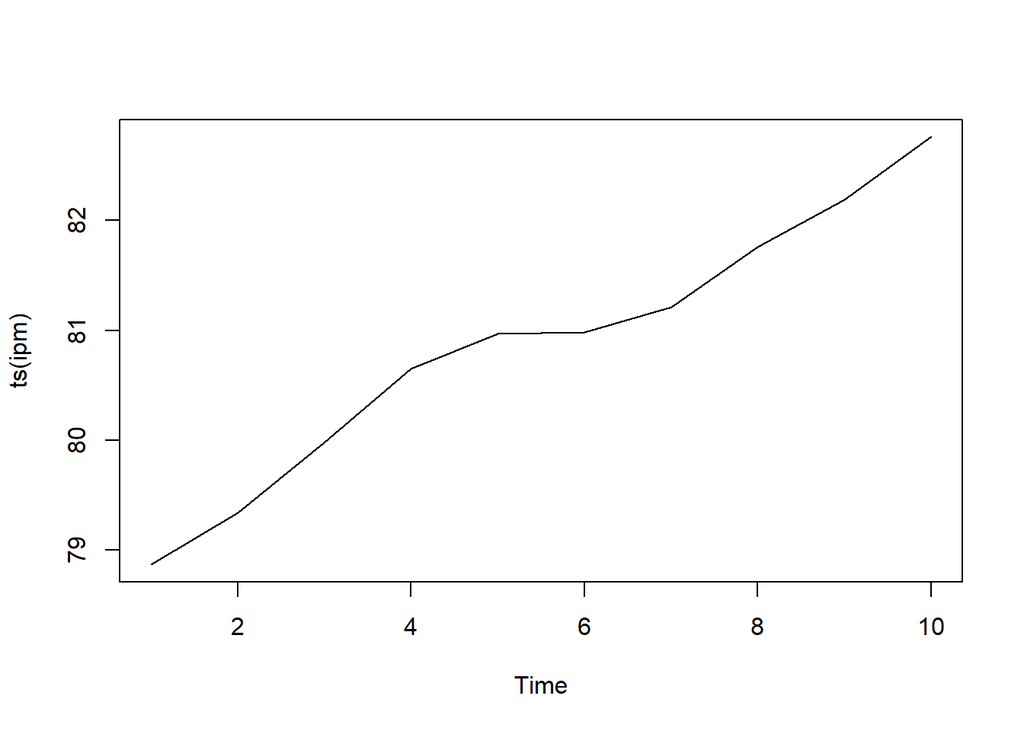

```r
# Visualisasi Data IPM
plot(ts(ipm))
```

### Tahap 2: Membuat Model Awal (Tersangka Utama)

Kita akan membuat model regresi linear sederhana untuk memprediksi `ipm` berdasarkan `tahun`. Di tahap ini, kita berasumsi modelnya baik-baik saja.

```r
# Membuat model regresi OLS (Ordinary Least Squares)
model_awal <- lm(ipm ~ tahun, data = dt_ipm)
summary(model_awal)
```

```
##
## Call:
## lm(formula = ipm ~ tahun, data = dt_ipm)
##
## Residuals:
##      Min       1Q   Median       3Q      Max
## -0.25691 -0.13145 -0.08055  0.10195  0.37491
##
## Coefficients:
##               Estimate Std. Error t value Pr(>|t|)
## (Intercept) -721.42127   50.03118  -14.42 5.23e-07 ***
## tahun          0.39727    0.02477   16.04 2.29e-07 ***
## ---
## Signif. codes:  0 '***' 0.001 '**' 0.01 '*' 0.05 '.' 0.1 ' ' 1
##
## Residual standard error: 0.225 on 8 degrees of freedom
## Multiple R-squared:  0.9698, Adjusted R-squared:  0.9661
## F-statistic: 257.1 on 1 and 8 DF,  p-value: 2.294e-07
```

**Observasi Awal:**

Lihat! **Nilai Adjusted R-squared sangat tinggi (0.9661)** dan koefisien `tahun` **sangat signifikan (p-value < 0.001)**. Jika kita berhenti di sini, kita akan menyimpulkan ini adalah model yang fantastis. Tapi seorang detektif yang baik tidak akan berhenti di permukaan.

### Tahap 3: Diagnosis (Investigasi Sisaan)

Sekarang kita akan memeriksa “TKP”, yaitu **sisaan (residuals)** dari model kita. Apakah ada pola aneh?

#### 3.1. Diagnosis Visual

Kita akan plot sisaan untuk melihat apakah ada pola yang mencurigakan.

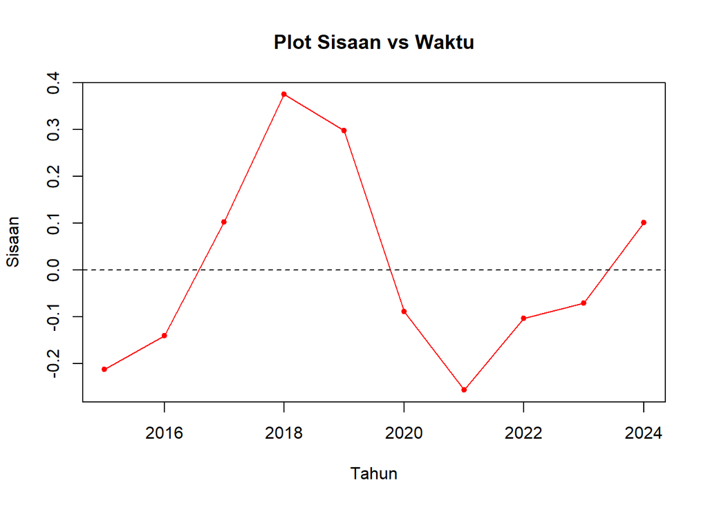

```r
# Ambil sisaan dari model
sisaan_awal <- residuals(model_awal)

# Plot sisaan terhadap waktu
plot(dt_ipm$tahun, sisaan_awal, type="o", pch=20, col="red",
     main="Plot Sisaan vs Waktu", xlab="Tahun", ylab="Sisaan")
abline(h=0, lty=2) # Garis referensi di y=0
```

**Kecurigaan:**

Plot di atas menunjukkan pola yang **tidak acak**. Perhatikan bagaimana sisaan cenderung berkelompok: titik pertama di bawah nol, lalu naik terus, dan turun lagi. Ini adalah gejala visual yang kuat dari autokorelasi positif. Sisaan positif cenderung diikuti sisaan positif, dan sebaliknya.

#### 3.2. Diagnosis Formal (Uji Durbin-Watson)

Visual saja tidak cukup, kita butuh bukti formal. Kita gunakan Uji Durbin-Watson.

- **H0 (Hipotesis Nol)**: Tidak ada autokorelasi. Sisaan saling bebas.
- **H1 (Hipotesis Alternatif)**: Ada autokorelasi.

```r
dwtest(model_awal)
```

```
##
##  Durbin-Watson test
##
## data:  model_awal
## DW = 0.93007, p-value = 0.006332
## alternative hypothesis: true autocorrelation is greater than 0
```

**Hasil Investigasi:**

- P-value yang dihasilkan **sangat kecil (0.006332)**, yaitu di bawah tingkat signifikansi 0.05.
- Kesimpulan: Kita **menolak H0**. Bukti sudah kuat. Model kita **terbukti menderita autokorelasi**.

### Tahap 4: Penanganan (Menyembuhkan Model)

Karena model kita “sakit”, kita perlu menanganinya. Kita akan coba dua metode.

#### Metode 1: Cochrane-Orcutt

**Intuisi:** Metode ini secara iteratif (berulang-ulang) mencoba menemukan “tingkat penularan” error (disebut rho, ρ), lalu menyesuaikan model sampai autokorelasinya hilang.

1. Teori Singkat: C-O adalah prosedur iteratif untuk mengestimasi koefisien regresi. Intinya adalah:
2. Estimasi koefisien autokorelasi sisaan, rho (ρ).
3. Gunakan ρ untuk mentransformasi variabel dependen (Y) dan independen (X) menjadi:
- $Y_t^* =Y_t−\rho Y_{t−1}$
- $X_t =X_t−\rho X_{t−1}$
4. Jalankan regresi OLS pada variabel yang sudah ditransformasi ($Y_t^*$ vs $X_t^*$).
5. Ulangi langkah 1-3 sampai nilai ρ konvergen.

```r
model_co <- cochrane.orcutt(model_awal)
summary(model_co)
```

```
## Call:
## lm(formula = ipm ~ tahun, data = dt_ipm)
##
##                Estimate  Std. Error t value  Pr(>|t|)
## (Intercept) -668.859674   92.729304  -7.213 0.0001755 ***
## tahun          0.371290    0.045886   8.092 8.475e-05 ***
## ---
## Signif. codes:  0 '***' 0.001 '**' 0.01 '*' 0.05 '.' 0.1 ' ' 1
##
## Residual standard error: 0.1891 on 7 degrees of freedom
## Multiple R-squared:  0.9034 ,  Adjusted R-squared:  0.8896
## F-statistic: 65.5 on 1 and 7 DF,  p-value: < 8.475e-05
##
## Durbin-Watson statistic
## (original):    0.93007 , p-value: 6.332e-03
## (transformed): 1.27987 , p-value: 4.302e-02
```

```r
# rho paling optimum
rho <- model_co$rho
cat("Rho optimum:", rho)
```

```
## Rho optimum: 0.467972
```

**Verifikasi Manual:**

```r
ipm.trans <- dt_ipm$ipm[-1] - dt_ipm$ipm[-10]*rho

tahun.trans <- dt_ipm$tahun[-1] - dt_ipm$tahun[-10]*rho
model_co_manual <- lm(ipm.trans~tahun.trans)

b0_co_manual <- coef(model_co_manual)[1]/(1-rho)
b1_co_manual <- coef(model_co_manual)[2]
cat("Koefisien manual Cochrane-Orcutt:\n")
```

```
## Koefisien manual Cochrane-Orcutt:
```

```r
cat("b0:", b0_co_manual, "\n")
```

```
## b0: -668.8597
```

```r
cat("b1:", b1_co_manual, "\n")
```

```
## b1: 0.3712904
```

**Perhatikan:** Hasil koefisien manual kita sangat mirip dengan hasil dari fungsi otomatis! Ini membuktikan bahwa kita memahami mekanisme di baliknya. (Catatan: Perbedaan kecil mungkin terjadi karena fungsi otomatis melakukan beberapa iterasi).

#### Metode 2: Hildreth-Lu

**Intuisi:** Metode ini lebih sistematis. Ia akan mencoba berbagai kemungkinan nilai ρ dan memilih satu yang menghasilkan **Sum of Squared Errors (SSE) terkecil.**

```r
#Penanganan Autokorelasi Hildreth lu
# Hildreth-Lu
hildreth.lu.func<- function(r, model){
  x <- model.matrix(model)[,-1]
  y <- model.response(model.frame(model))
  n <- length(y)
  t <- 2:n
  y <- y[t]-r*y[t-1]
  x <- x[t]-r*x[t-1]

  return(lm(y~x))
}

#Pencariab rho yang meminimumkan SSE
r <- c(seq(0.1,0.9, by= 0.1))
tab <- data.frame("rho" = r, "SSE" = sapply(r, function(i){deviance(hildreth.lu.func(i, model_awal))}))
round(tab, 4)
```

```
##   rho    SSE
## 1 0.1 0.3030
## 2 0.2 0.2783
## 3 0.3 0.2613
## 4 0.4 0.2521
## 5 0.5 0.2507
## 6 0.6 0.2571
## 7 0.7 0.2713
## 8 0.8 0.2932
## 9 0.9 0.3230
```

```r
#Rho optimal di sekitar 0.4
rOpt <- seq(0.4,0.6, by= 0.001)
tabOpt <- data.frame("rho" = rOpt, "SSE" = sapply(rOpt, function(i){deviance(hildreth.lu.func(i, model_awal))}))
head(tabOpt[order(tabOpt$SSE),])
```

```
##      rho       SSE
## 69 0.468 0.2503057
## 68 0.467 0.2503061
## 70 0.469 0.2503061
## 67 0.466 0.2503072
## 71 0.470 0.2503073
## 66 0.465 0.2503091
```

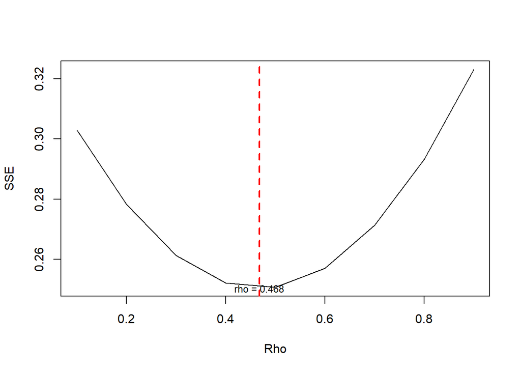

```r
#Grafik SSE optimum
par(mfrow = c(1,1))
plot(tab$SSE ~ tab$rho , type = "l", xlab = "Rho", ylab = "SSE")
abline(v = tabOpt[tabOpt$SSE==min(tabOpt$SSE),"rho"], lty = 2, col="red",lwd=2)
text(x=0.468, y=0.2503057, labels = "rho = 0.468", cex = 0.8)
```

```r
model_hl <- hildreth.lu(dt_ipm$ipm, dt_ipm$tahun, rho = 0.468)
summary(model_hl)
```

```
##
## Call:
## lm(formula = y ~ x)
##
## Residuals:
##      Min       1Q   Median       3Q      Max
## -0.25789 -0.12499  0.01473  0.09753  0.27048
##
## Coefficients:
##               Estimate Std. Error t value Pr(>|t|)
## (Intercept) -355.83235   49.33459  -7.213 0.000176 ***
## x              0.37129    0.04589   8.091 8.48e-05 ***
## ---
## Signif. codes:  0 '***' 0.001 '**' 0.01 '*' 0.05 '.' 0.1 ' ' 1
##
## Residual standard error: 0.1891 on 7 degrees of freedom
## Multiple R-squared:  0.9034, Adjusted R-squared:  0.8896
## F-statistic: 65.47 on 1 and 7 DF,  p-value: 8.478e-05
```

```r
#Transformasi Balik
cat("y = ", coef(model_hl)[1]/(1-0.468), "+", coef(model_hl)[2],"x", sep = "")
```

```
## y = -668.8578+0.3712895x
```

```r
#Deteksi autokorelasi
dwtest(model_hl)
```

```
##
##  Durbin-Watson test
##
## data:  model_hl
## DW = 1.2799, p-value = 0.04302
## alternative hypothesis: true autocorrelation is greater than 0
```

### Tahap 5: Evaluasi Akhir

Mari kita bandingkan SSE dan Statistik Durbin-Watson dari ketiga model untuk melihat seberapa efektif penanganan kita.

```r
# Menghitung SSE untuk setiap model secara manual
sse_awal <- sum(residuals(model_awal)^2)
sse_co <- sum(residuals(model_co)^2)
sse_hl <- sum(residuals(model_hl)^2)

# Membuat tabel perbandingan
data.frame(
  Metode = c("Model Awal (Sakit)", "Cochrane-Orcutt (Sehat)", "Hildreth-Lu (Sehat)"),
  SSE = c(sse_awal, sse_co, sse_hl),
  DW_Statistic = c(dwtest(model_awal)$statistic, model_co$DW[3], dwtest(model_hl)$statistic)
)
```

```
##                    Metode       SSE DW_Statistic
## 1      Model Awal (Sakit) 0.4050764    0.9300685
## 2 Cochrane-Orcutt (Sehat) 0.5422822    1.2798710
## 3     Hildreth-Lu (Sehat) 0.2503057    1.2798744
```